# Gender bias in Bioinformatics - Coauthors

### Distribution of coauthors by gender

#### Male authors

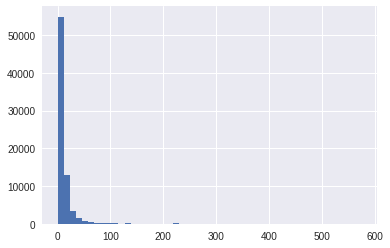

```python
coauthors_gen_dist.loc[coauthors_gen_dist['gender']=='male', 'total_coauthors'].hist(bins=50)
```

```python
coauthors_gen_dist.loc[coauthors_gen_dist['gender']=='male', 'total_coauthors'].describe()
```

```
count    75268.000000
mean        11.899692
std         20.617676
min          0.000000
25%          4.000000
50%          7.000000
75%         12.000000
max        576.000000
Name: total_coauthors, dtype: float64
```

#### Female authors

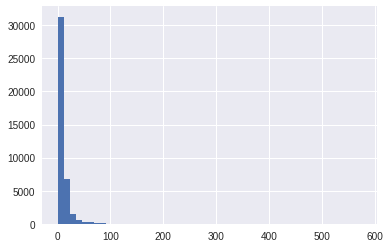

```python
coauthors_gen_dist.loc[coauthors_gen_dist['gender']=='female', 'total_coauthors'].hist(bins=50)
```

```python
coauthors_gen_dist.loc[coauthors_gen_dist['gender']=='female', 'total_coauthors'].describe()
```

```
count    40987.000000
mean        10.665235
std         18.578797
min          0.000000
25%          4.000000
50%          7.000000
75%         11.000000
max        576.000000
Name: total_coauthors, dtype: float64
```

### Relationship between number of colaborators and productivity

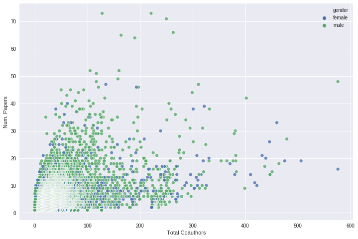

```python
plt.figure(1, figsize=(12, 8))
fig = sns.scatterplot('total_coauthors', 'papers', data=coauthors_gen_dist, hue='gender',
                      alpha=0.8, x_jitter=0.5, y_jitter=0.5)
fig.set(xlabel='Total Coauthors', ylabel='Num. Papers')
plt.show()
```

```python
corr, _ = pearsonr(coauthors_gen_dist['total_coauthors'], coauthors_gen_dist['papers'])
print('Pearsons correlation: %.3f' % corr)
```

```
Pearsons correlation: 0.563
```

#### Male authors

```python
male_authors = coauthors_gen_dist[coauthors_gen_dist['gender']=='male']
corr, _ = pearsonr(male_authors['total_coauthors'], male_authors['papers'])
print('Pearsons correlation: %.3f' % corr)
```

```
Pearsons correlation: 0.576
```

#### Female authors

```python
female_authors = coauthors_gen_dist[coauthors_gen_dist['gender']=='female']
corr, _ = pearsonr(female_authors['total_coauthors'], female_authors['papers'])
print('Pearsons correlation: %.3f' % corr)
```

```
Pearsons correlation: 0.544
```

It seems there is a correlation between the number of coauthors and productivity. The correlation is a bit stronger for male than for female authors

### Gender distribution of coauthors

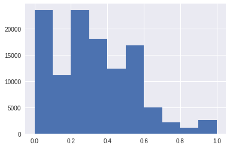

```python
coauthors_gen_dist['prop_female'].hist()
```

```python
# replace NaN values with 0. NaN values are associated with authors who don't have coauthors or the
# gender of their coauthors are unknown
coauthors_gen_dist.loc[coauthors_gen_dist['prop_female'].isnull(),'prop_female'] = 0
coauthors_gen_dist.loc[coauthors_gen_dist['prop_male'].isnull(),'prop_male'] = 0
```

```python
coauthors_gen_dist['prop_female'].describe()
```

```
count    116255.000000
mean          0.311369
std           0.229764
min           0.000000
25%           0.142857
50%           0.300000
75%           0.460000
max           1.000000
Name: prop_female, dtype: float64
```

#### Proportion of female coauthors for *`male`* authors

```python
coauthors_gen_dist.loc[coauthors_gen_dist['gender']=='male', 'prop_female'].mean()
```

```
0.29041988010515324
```

#### Proportion of female coauthors for *`female`* authors

```python
coauthors_gen_dist.loc[coauthors_gen_dist['gender']=='female', 'prop_female'].mean()
```

```
0.3498396070968412
```

Check if difference is significant

```python
ttest, pval = ttest_ind(coauthors_gen_dist.loc[coauthors_gen_dist['gender']=='male', 'prop_female'],
                        coauthors_gen_dist.loc[coauthors_gen_dist['gender']=='female', 'prop_female'])
print('T val: {0}, p-val: {1}'.format(ttest, pval))
```

```
T val: -42.45314330709345, p-val: 0.0
```

Female authors collaborate significantly more with women (mean=0.35) than male authors (mean=0.29)

### Productivity and coauthors gender distribution

```python
# sort dataframe by papers (productivity)
coauthors_gen_dist.sort_values('papers', inplace=True, ascending=False)
# add a column to indicate the ranking of authors by their productivity.
# high-ranked authors are the most productive
coauthors_gen_dist['ranking'] = np.arange(1, coauthors_gen_dist.shape[0]+1)
```

```python
# show the top-10 most productivy authors
coauthors_gen_dist.head(10)
```

|  | id | name | gender | papers | num_male_coauthors | num_female_coauthors | ratio_female_male | ranking | prop_female | prop_male | total_coauthors |
| --- | --- | --- | --- | --- | --- | --- | --- | --- | --- | --- | --- |
| 12665 | 24755400900 | Mark B Gerstein | male | 73 | 96.0 | 32.0 | 0.333333 | 1 | 0.250000 | 0.750000 | 128.0 |
| 553 | 7102702401 | Peter F Stadler | male | 73 | 158.0 | 63.0 | 0.398734 | 2 | 0.285068 | 0.714932 | 221.0 |
| 5460 | 7007165509 | Janusz M Bujnicki | male | 71 | 147.0 | 103.0 | 0.700680 | 3 | 0.412000 | 0.588000 | 250.0 |
| 23639 | 7103061421 | Peer Bork | male | 66 | 186.0 | 77.0 | 0.413978 | 4 | 0.292776 | 0.707224 | 263.0 |
| 781 | 18133480200 | Joaquín Dopazo | male | 65 | 124.0 | 40.0 | 0.322581 | 5 | 0.243902 | 0.756098 | 164.0 |
| 9126 | 16308427600 | Alfonso Valencia | male | 64 | 141.0 | 49.0 | 0.347518 | 6 | 0.257895 | 0.742105 | 190.0 |
| 4148 | 35458582500 | Philip E Bourne | male | 52 | 127.0 | 33.0 | 0.259843 | 7 | 0.206250 | 0.793750 | 160.0 |
| 12069 | 7102482003 | William Stafford Noble | male | 52 | 92.0 | 13.0 | 0.141304 | 8 | 0.123810 | 0.876190 | 105.0 |
| 2682 | 6604065270 | Rolf Backofen | male | 51 | 82.0 | 35.0 | 0.426829 | 9 | 0.299145 | 0.700855 | 117.0 |
| 10631 | 7005602630 | David S Wishart | male | 49 | 101.0 | 57.0 | 0.564356 | 10 | 0.360759 | 0.639241 | 158.0 |

#### Explore the **`100 most`** productive authors

```python
max_authors = 100
```

```python
coauthors_gen_dist.head(max_authors).prop_female.describe()
```

```
count    100.000000
mean       0.294196
std        0.069821
min        0.123810
25%        0.251476
50%        0.283921
75%        0.329030
max        0.511628
Name: prop_female, dtype: float64
```

Male authors

```python
coauthors_gen_dist.loc[coauthors_gen_dist['gender']=='male'].head(max_authors).prop_female.mean()
```

```
0.2849878705268327
```

Female authors

```python
coauthors_gen_dist.loc[coauthors_gen_dist['gender']=='female'].head(max_authors).prop_female.mean()
```

```
0.34596942724037694
```

#### Explore the **`100 less`** productive authors

```python
coauthors_gen_dist.tail(max_authors).prop_female.describe()
```

```
count    100.000000
mean       0.242222
std        0.428554
min        0.000000
25%        0.000000
50%        0.000000
75%        0.055556
max        1.000000
Name: prop_female, dtype: float64
```

Male authors

```python
coauthors_gen_dist.loc[coauthors_gen_dist['gender']=='male'].tail(max_authors).prop_female.mean()
```

```
0.2222222222222222
```

Female authors

```python
coauthors_gen_dist.loc[coauthors_gen_dist['gender']=='female'].tail(max_authors).prop_female.mean()
```

```
0.26
```

#### Productivity (number of papers) and proportion of female coauthors

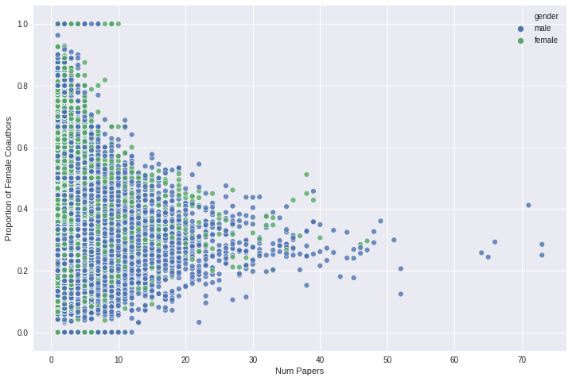

```python
plt.figure(1, figsize=(12, 8))
fig = sns.scatterplot('papers', 'prop_female', data=coauthors_gen_dist, hue='gender', alpha=0.8)
fig.set(xlabel='Num Papers', ylabel='Proportion of Female Coauthors')
plt.show()
```

```python
corr, _ = pearsonr(coauthors_gen_dist['papers'], coauthors_gen_dist['prop_female'])
print('Pearsons correlation: %.3f' % corr)
```

```
Pearsons correlation: -0.004
```

In general, there is not correlation between the researchers' productivity and the proportion of female coauthors.

#### Productivity and proportion of female coauthors for `male` authors

```python
corr, _ = pearsonr(coauthors_gen_dist.loc[coauthors_gen_dist['gender']=='male','papers'],
                   coauthors_gen_dist.loc[coauthors_gen_dist['gender']=='male','prop_female'])
print('Pearsons correlation: %.3f' % corr)
```

```
Pearsons correlation: 0.012
```

#### Productivity and proportion of female coauthors for `female` authors

```python
corr, _ = pearsonr(coauthors_gen_dist.loc[coauthors_gen_dist['gender']=='female','papers'],
                   coauthors_gen_dist.loc[coauthors_gen_dist['gender']=='female','prop_female'])
print('Pearsons correlation: %.3f' % corr)
```

```
Pearsons correlation: -0.006
```

#### Male authors that have collaborated more with women

```python
o_coauthors_gen_dist = coauthors_gen_dist.sort_values('prop_female', inplace=False, ascending=False)
o_coauthors_gen_dist.loc[coauthors_gen_dist['gender']=='male'].head(10)
```

|  | id | name | gender | papers | num_male_coauthors | num_female_coauthors | ratio_female_male | ranking | prop_female | prop_male | total_coauthors |
| --- | --- | --- | --- | --- | --- | --- | --- | --- | --- | --- | --- |
| 135938 | 57091167500 | Jasper Ubirajara Chao | male | 1 | 0.0 | 3.0 | 0.0 | 88683 | 1.0 | 0.0 | 3.0 |
| 73432 | 55305469400 | Sehyun Chae | male | 1 | 0.0 | 2.0 | 0.0 | 114144 | 1.0 | 0.0 | 2.0 |
| 11459 | 35185614100 | Rui Song | male | 1 | 0.0 | 1.0 | 0.0 | 104010 | 1.0 | 0.0 | 1.0 |
| 9321 | 35069298500 | Jesse Eickholt | male | 9 | 0.0 | 1.0 | 0.0 | 2130 | 1.0 | 0.0 | 1.0 |
| 117194 | 16073156900 | Souvik Modi | male | 1 | 0.0 | 2.0 | 0.0 | 114161 | 1.0 | 0.0 | 2.0 |
| 23399 | 9335876500 | Robin E C Lee | male | 1 | 0.0 | 1.0 | 0.0 | 104012 | 1.0 | 0.0 | 1.0 |
| 99571 | 7003538237 | Andrew K Dingwall | male | 1 | 0.0 | 1.0 | 0.0 | 104023 | 1.0 | 0.0 | 1.0 |
| 64031 | 57202672540 | Sivakumar Kannan | male | 1 | 0.0 | 1.0 | 0.0 | 104025 | 1.0 | 0.0 | 1.0 |
| 139670 | 34167818700 | Philipp Gebhardt | male | 1 | 0.0 | 1.0 | 0.0 | 104028 | 1.0 | 0.0 | 1.0 |
| 63924 | 25642376600 | Jong-Sook Ahn | male | 1 | 0.0 | 1.0 | 0.0 | 104033 | 1.0 | 0.0 | 1.0 |

#### Authors segmentation

Segmenting authors by productivity

```python
segment_size = 100
segment_limits = np.arange(100, coauthors_gen_dist.shape[0], segment_size)
total_segments = len(group_limits)
s_coauthors_gen_dist = pd.DataFrame(columns=['segment', 'mean_papers', 'mean_prop_female'])
start_idx = 0

for i in range(total_segments):
    end_idx = segment_limits[i]
    segment_dict = {
        'segment': int(i+1),
        'mean_papers': coauthors_gen_dist[(coauthors_gen_dist['ranking']>start_idx)&
                                          (coauthors_gen_dist['ranking']<=end_idx)].papers.mean(),
        'mean_prop_female': coauthors_gen_dist[(coauthors_gen_dist['ranking']>start_idx)&
                                               (coauthors_gen_dist['ranking']<=end_idx)].prop_female.mean()
    }
    s_coauthors_gen_dist = s_coauthors_gen_dist.append(segment_dict, ignore_index=True)
    start_idx = end_idx

s_coauthors_gen_dist.head()
```

|  | segment | mean_papers | mean_prop_female |
| --- | --- | --- | --- |
| 0 | 1.0 | 38.96 | 0.294196 |
| 1 | 2.0 | 26.31 | 0.294015 |
| 2 | 3.0 | 21.84 | 0.292519 |
| 3 | 4.0 | 19.38 | 0.310726 |
| 4 | 5.0 | 17.79 | 0.294899 |

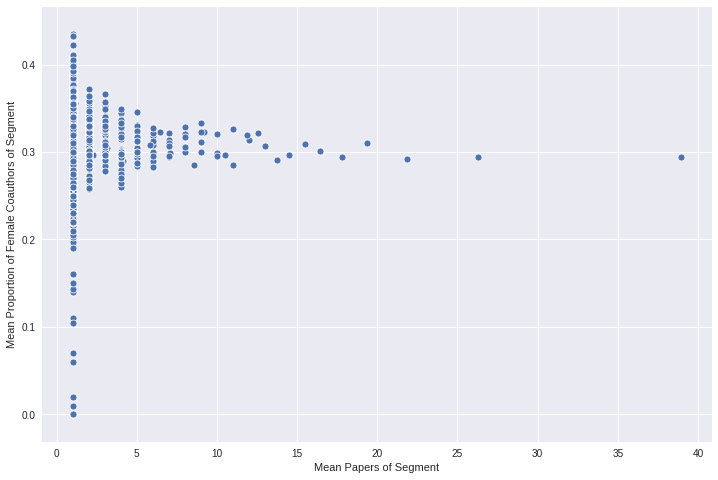

```python
fig = plt.figure(1, figsize=(12, 8))
fig = sns.scatterplot('mean_papers', 'mean_prop_female', data=s_coauthors_gen_dist)
fig.set(xlabel='Mean Papers of Segment', ylabel='Mean Proportion of Female Coauthors of Segment')
plt.show()
```

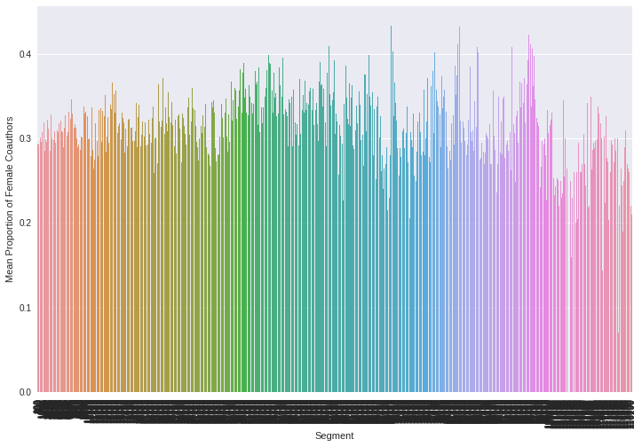

```python
plt.figure(1, figsize=(12, 8))
fig = sns.barplot('segment', 'mean_prop_female', data=s_coauthors_gen_dist)
fig.set(xlabel='Segment', ylabel='Mean Proportion of Female Coauthors')
fig.set_xticklabels(labels=group_limits,rotation=90)
plt.show()
```

Independently of the segement the mean proportion of female coauthors appear to be some how uniform.

#### Segmenting `male` authors by productivity (number of papers)

```python
group_limits = np.arange(100, coauthors_gen_dist.shape[0], segment_size)
total_groups = len(group_limits)
s_coauthors_gen_dist = pd.DataFrame(columns=['segment', 'mean_papers', 'mean_prop_female'])
start_idx = 0

for i in range(total_groups):
    end_idx = group_limits[i]
    sub_set = coauthors_gen_dist[(coauthors_gen_dist['ranking']>start_idx)&
                                 (coauthors_gen_dist['ranking']<=end_idx)&
                                 (coauthors_gen_dist['gender']=='male')]
    group_dict = {
        'segment': int(i+1),
        'mean_papers': sub_set.papers.mean(),
        'mean_prop_female': sub_set.ratio_female_male.median()
    }
    s_coauthors_gen_dist = s_coauthors_gen_dist.append(group_dict, ignore_index=True)
    start_idx = end_idx

s_coauthors_gen_dist.head()
```

|  | segment | mean_papers | mean_prop_female |
| --- | --- | --- | --- |
| 0 | 1.0 | 39.364706 | 0.377622 |
| 1 | 2.0 | 26.329412 | 0.397590 |
| 2 | 3.0 | 21.847059 | 0.386364 |
| 3 | 4.0 | 19.370370 | 0.405405 |
| 4 | 5.0 | 17.835294 | 0.393939 |

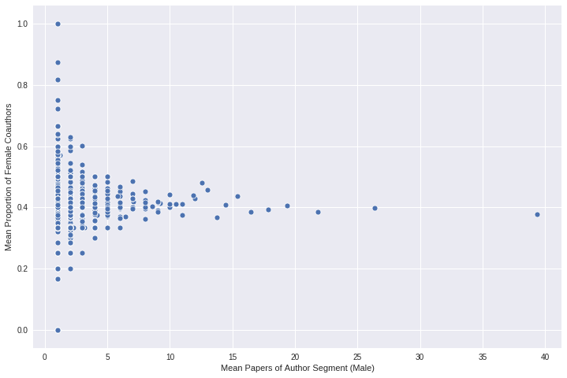

```python
fig = plt.figure(1, figsize=(12, 8))
fig = sns.scatterplot('mean_papers', 'mean_prop_female', data=s_coauthors_gen_dist)
fig.set(xlabel='Mean Papers of Author Segment (Male)', ylabel='Mean Proportion of Female Coauthors')
plt.show()
```

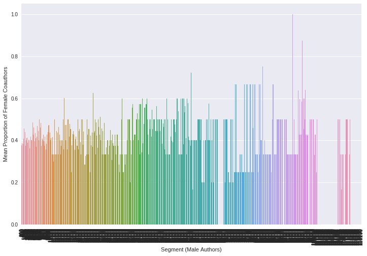

```python
plt.figure(1, figsize=(12, 8))
fig = sns.barplot('segment', 'mean_prop_female', data=s_coauthors_gen_dist)
fig.set(xlabel='Segment (Male Authors)', ylabel='Mean Proportion of Female Coauthors')
fig.set_xticklabels(labels=group_limits,rotation=90)
plt.show()
```

#### Segmenting `female` authors by productivity (number of papers)

```python
group_limits = np.arange(100, coauthors_gen_dist.shape[0], 100)
total_groups = len(group_limits)
s_coauthors_gen_dist = pd.DataFrame(columns=['segment', 'mean_papers', 'mean_prop_female'])
start_idx = 0

for i in range(total_groups):
    end_idx = group_limits[i]
    sub_set = coauthors_gen_dist[(coauthors_gen_dist['ranking']>start_idx)&
                                 (coauthors_gen_dist['ranking']<=end_idx)&
                                 (coauthors_gen_dist['gender']=='female')]
    group_dict = {
        'segment': int(i+1),
        'mean_papers': sub_set.papers.mean(),
        'mean_prop_female': sub_set.ratio_female_male.median()
    }
    s_coauthors_gen_dist = s_coauthors_gen_dist.append(group_dict, ignore_index=True)
    start_idx = end_idx
```

```python
s_coauthors_gen_dist.head(10)
```

|  | segment | mean_papers | mean_prop_female |
| --- | --- | --- | --- |
| 0 | 1.0 | 36.666667 | 0.532258 |
| 1 | 2.0 | 26.200000 | 0.467290 |
| 2 | 3.0 | 21.800000 | 0.553191 |
| 3 | 4.0 | 19.421053 | 0.583333 |
| 4 | 5.0 | 17.533333 | 0.430769 |
| 5 | 6.0 | 16.375000 | 0.530488 |
| 6 | 7.0 | 15.684211 | 0.450000 |
| 7 | 8.0 | 14.631579 | 0.413793 |
| 8 | 9.0 | 13.812500 | 0.501466 |
| 9 | 10.0 | 13.000000 | 0.409091 |

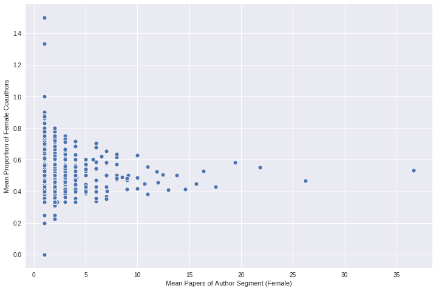

```python
fig = plt.figure(1, figsize=(12, 8))
fig = sns.scatterplot('mean_papers', 'mean_prop_female', data=s_coauthors_gen_dist)
fig.set(xlabel='Mean Papers of Author Segment (Female)', ylabel='Mean Proportion of Female Coauthors')
plt.show()
```

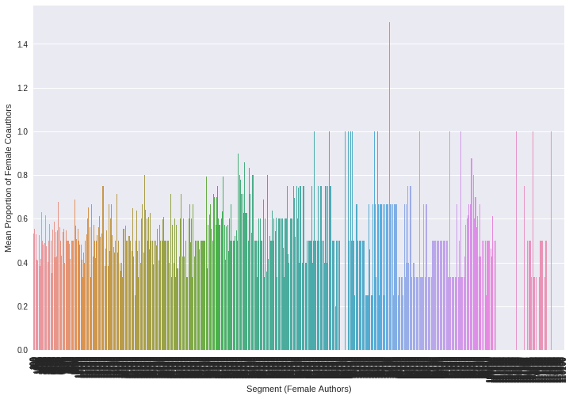

```python
plt.figure(1, figsize=(12, 8))
fig = sns.barplot('segment', 'mean_prop_female', data=s_coauthors_gen_dist)
fig.set(xlabel='Segment (Female Authors)', ylabel='Mean Proportion of Female Coauthors')
fig.set_xticklabels(labels=group_limits,rotation=90)
plt.show()
```

### Evolution over time of gender couthors distribution

In the following the distribution of coauthors gender are grouped by year. Only author with more than five years of publication activity will be considered. The restriction was applied because it would be hard to explore "evolution" in less than five years.

```python
# We define five years as the minimum number years to consider that there is an "evolution" in time
min_num_years = 5

def compute_evolution_gender_distribution(author):
    author_id = author['id']
    print('Processing author: {}'.format(author_id))
    author_info = authors[authors['id']==author_id]
    paper_ids = papers_authors.loc[papers_authors['author_id']==author_id, ['id', 'year']]
    author_papers = papers_authors.loc[papers_authors['id'].isin(paper_ids['id'])]
    co_authors = author_papers.loc[author_papers['author_id']!=author_id]
    g_co_authors = co_authors.groupby('year', sort=True, as_index=False)
    years = list(g_co_authors.groups.keys())
    if len(years) >= min_num_years:
        males = g_co_authors.apply(lambda x: (x['author_gender']=='male').sum())
        females = g_co_authors.apply(lambda x: (x['author_gender']=='female').sum())
        return pd.DataFrame.from_dict(
            {
                'id': author_id,
                'name': author_info['name'].values[0],
                'gender': author_info['gender'].values[0],
                'total_papers': author_info['papers'].values[0],
                'years': years,
                'num_male_coauthors': males,
                'num_female_coauthors': females,
                'total_coauthors': males+females,
                'prop_female_coauthors': females/(males+females),
                'prop_male_coauthors': males/(males+females)
            })
    else:
        print('Author discarded, she does not have a publication record of more \
               than {} years'.format(min_num_years))
        return None
```

```python
coauthors_gen_dist_time = pd.DataFrame()
for index, author in authors.iterrows():
    author_evolution = compute_evolution_gender_distribution(author)
    if author_evolution is not None:
        coauthors_gen_dist_time = coauthors_gen_dist_time.append(author_evolution, ignore_index=True)
```

```python
coauthors_gen_dist_time.head()
```

|  | id | name | gender | total_papers | years | num_male_coauthors | num_female_coauthors | total_coauthors | prop_female_coauthors | prop_male_coauthors |
| --- | --- | --- | --- | --- | --- | --- | --- | --- | --- | --- |
| 0 | 24755400900 | Mark B Gerstein | male | 73 | 2005 | 7 | 2 | 9 | 0.222222 | 0.777778 |
| 1 | 24755400900 | Mark B Gerstein | male | 73 | 2006 | 27 | 5 | 32 | 0.156250 | 0.843750 |
| 2 | 24755400900 | Mark B Gerstein | male | 73 | 2007 | 30 | 3 | 33 | 0.090909 | 0.909091 |
| 3 | 24755400900 | Mark B Gerstein | male | 73 | 2008 | 13 | 1 | 14 | 0.071429 | 0.928571 |
| 4 | 24755400900 | Mark B Gerstein | male | 73 | 2009 | 21 | 6 | 27 | 0.222222 | 0.777778 |

```python
file_name = 'coauthors_gender_distribution_over_time.csv'
try:
    with open(os.path.join(file_name), "r") as f:
        coauthors_gen_dist_time = pd.read_csv(f)
        print("Read from existing file: {}".format(file_name))
except:
    print("Could not find the file, going to compute the gender distribution of coauthors over time. \
           It will take a while")
    coauthors_gen_dist_time = pd.DataFrame()
    for index, author in authors.iterrows():
        author_evolution = compute_evolution_gender_distribution(author)
        if author_evolution is not None:
            coauthors_gen_dist_time = coauthors_gen_dist_time.append(author_evolution, ignore_index=True)
    coauthors_gen_dist_time.to_csv(file_name, index=False)
```

#### General evolution of all authors

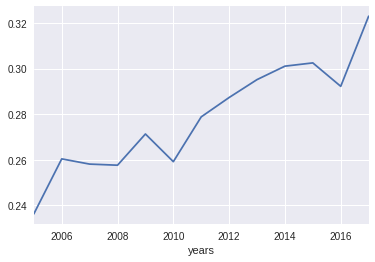

```python
coauthors_gen_dist_time.groupby('years')['prop_female_coauthors'].agg(np.mean).plot.line(x='years', y='prop_female_coauthors')
```

#### Evolution of male authors

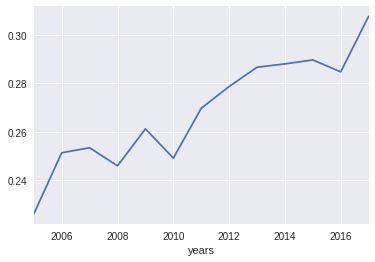

```python
coauthors_gen_dist_time[coauthors_gen_dist_time['gender']=='male'].groupby('years')['prop_female_coauthors'].agg(np.mean).plot.line(x='years', y='prop_female_coauthors')
```

#### Evolution of female authors

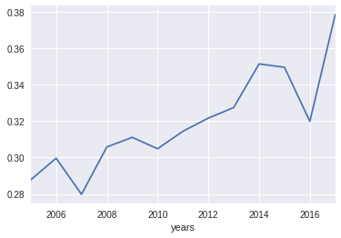

```python
coauthors_gen_dist_time[coauthors_gen_dist_time['gender']=='female'].groupby('years')['prop_female_coauthors'].agg(np.mean).plot.line(x='years', y='prop_female_coauthors')
```

#### Evolution of the top-X most productive authors

```python
productivity_limit = 10
```

```python
id_top_x_most_productive_authors = authors.sort_values('papers', ascending=False).head(productivity_limit).id.values
```

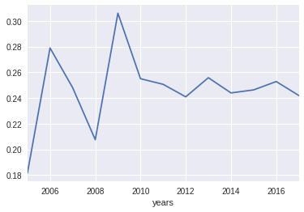

```python
coauthors_gen_dist_time[coauthors_gen_dist_time['id'].isin(id_top_x_most_productive_authors)].groupby('years')['prop_female_coauthors'].agg(np.mean).plot()
```

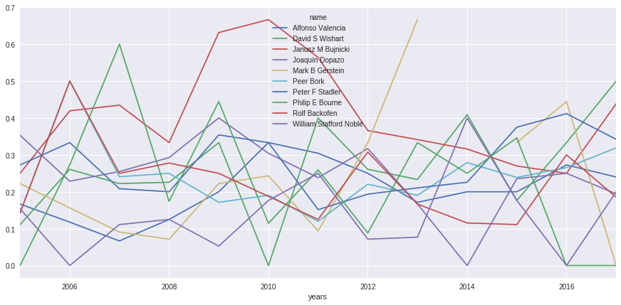

```python
fig, ax = plt.subplots(figsize=(15,7))
coauthors_gen_dist_time[coauthors_gen_dist_time['id'].isin(id_top_x_most_productive_authors)].groupby(['years', 'name'])['prop_female_coauthors'].agg(np.mean).unstack().plot(ax=ax)
```

```python
coauthors_gen_dist_time[coauthors_gen_dist_time['id'].isin(id_top_x_most_productive_authors)].groupby(['years', 'name'])['prop_female_coauthors'].agg(np.mean).unstack()
```

| name years | Alfonso Valencia | David S Wishart | Janusz M Bujnicki | Joaquín Dopazo | Mark B Gerstein | Peer Bork | Peter F Stadler | Philip E Bourne | Rolf Backofen | William Stafford Noble |
| --- | --- | --- | --- | --- | --- | --- | --- | --- | --- | --- |
| 2005 | 0.166667 | 0.111111 | 0.250000 | 0.352941 | 0.222222 | 0.142857 | 0.272727 | 0.000000 | 0.142857 | 0.153846 |
| 2006 | 0.117647 | 0.260870 | 0.419355 | 0.228571 | 0.156250 | 0.500000 | 0.333333 | 0.272727 | 0.500000 | 0.000000 |
| 2007 | 0.066667 | 0.222222 | 0.434783 | 0.254902 | 0.090909 | 0.240741 | 0.208333 | 0.600000 | 0.250000 | 0.111111 |
| 2008 | 0.125000 | 0.225806 | 0.333333 | 0.292683 | 0.071429 | 0.250000 | 0.200000 | 0.173913 | 0.277778 | 0.125000 |
| 2009 | 0.200000 | 0.333333 | 0.631579 | 0.400000 | 0.222222 | 0.171429 | 0.354167 | 0.444444 | 0.250000 | 0.052632 |
| 2010 | 0.333333 | 0.000000 | 0.666667 | 0.304348 | 0.243243 | 0.190476 | 0.333333 | 0.114286 | 0.187500 | 0.176471 |
| 2011 | 0.304348 | 0.400000 | 0.564103 | 0.238095 | 0.093750 | 0.120000 | 0.151515 | 0.259259 | 0.125000 | 0.250000 |
| 2012 | 0.250000 | 0.260870 | 0.365854 | 0.317073 | 0.333333 | 0.220588 | 0.193548 | 0.088235 | 0.307692 | 0.071429 |
| 2013 | 0.171429 | 0.233333 | 0.341463 | 0.166667 | 0.666667 | 0.190476 | 0.210526 | 0.333333 | 0.166667 | 0.076923 |
| 2014 | 0.200000 | 0.409091 | 0.315789 | 0.000000 | NaN | 0.279070 | 0.225806 | 0.250000 | 0.115385 | 0.400000 |
| 2015 | 0.200000 | 0.176471 | 0.269841 | 0.235294 | 0.333333 | 0.238806 | 0.375000 | 0.346154 | 0.111111 | 0.176471 |
| 2016 | 0.272727 | 0.333333 | 0.250000 | 0.250000 | 0.444444 | 0.265306 | 0.411765 | 0.000000 | 0.300000 | 0.000000 |
| 2017 | 0.240000 | 0.500000 | 0.438596 | 0.194444 | 0.000000 | 0.318841 | 0.342105 | 0.000000 | 0.185185 | 0.200000 |

#### Evolution of the top-X less productive authors

```python
id_top_x_less_productive_authors = coauthors_gen_dist_time.sort_values('total_papers').id.unique()[:productivity_limit]
```

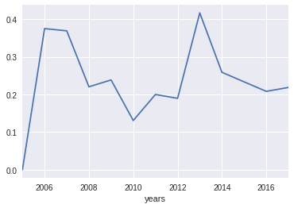

```python
coauthors_gen_dist_time[coauthors_gen_dist_time['id'].isin(id_top_x_less_productive_authors)].groupby('years')['prop_female_coauthors'].agg(np.mean).plot()
```

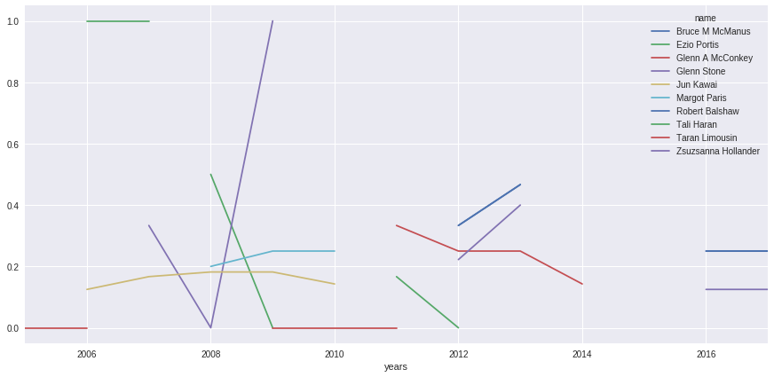

```python
fig, ax = plt.subplots(figsize=(15,7))
coauthors_gen_dist_time[coauthors_gen_dist_time['id'].isin(id_top_x_less_productive_authors)].groupby(['years', 'name'])['prop_female_coauthors'].agg(np.mean).unstack().plot(ax=ax)
```

```python
coauthors_gen_dist_time[coauthors_gen_dist_time['id'].isin(id_top_x_less_productive_authors)].groupby(['years', 'name'])['prop_female_coauthors'].agg(np.mean).unstack()
```

| name years | Bruce M McManus | Ezio Portis | Glenn A McConkey | Glenn Stone | Jun Kawai | Margot Paris | Robert Balshaw | Tali Haran | Taran Limousin | Zsuzsanna Hollander |
| --- | --- | --- | --- | --- | --- | --- | --- | --- | --- | --- |
| 2005 | NaN | NaN | 0.0 | NaN | NaN | NaN | NaN | NaN | NaN | NaN |
| 2006 | NaN | NaN | 0.0 | NaN | 0.125000 | NaN | NaN | 1.000 | NaN | NaN |
| 2007 | 0.285714 | NaN | NaN | 0.333333 | 0.166667 | NaN | 0.285714 | 1.000 | NaN | 0.142857 |
| 2008 | NaN | 0.500000 | NaN | 0.000000 | 0.181818 | 0.200000 | NaN | NaN | NaN | NaN |
| 2009 | NaN | 0.000000 | 0.0 | 1.000000 | 0.181818 | 0.250000 | NaN | 0.000 | NaN | NaN |
| 2010 | NaN | NaN | 0.0 | NaN | 0.142857 | 0.250000 | NaN | NaN | NaN | NaN |
| 2011 | NaN | 0.166667 | 0.0 | 0.000000 | NaN | NaN | NaN | 0.500 | 0.333333 | NaN |
| 2012 | 0.333333 | 0.000000 | NaN | NaN | NaN | 0.000000 | 0.333333 | NaN | 0.250000 | 0.222222 |
| 2013 | 0.466667 | NaN | NaN | 0.500000 | NaN | NaN | 0.466667 | NaN | 0.250000 | 0.400000 |
| 2014 | NaN | 0.375000 | NaN | NaN | NaN | 0.142857 | NaN | 0.375 | 0.142857 | NaN |
| 2016 | 0.250000 | NaN | NaN | NaN | NaN | NaN | 0.250000 | NaN | NaN | 0.125000 |
| 2017 | 0.250000 | NaN | NaN | NaN | NaN | NaN | 0.250000 | NaN | 0.250000 | 0.125000 |

## Análisis pendientes:

1. Distribución de género en papers más citados
2. Evolucion de genero (primer y último autor)
3. Evolución de sentimiento por año (o rango de años)
4. Distribución de temáticas por género
5. Evolución tématicas por año (general, hombres, mujeres)
6. Comparar revistas (por año, por género, por citas). Agrupar revistas (2 grupos, grupo 1=Nucleic, BMC Genomic, Bioinformatics, grupo 2=BMC Bioinformatics, Plos)
7. Afiliación por país, ciudad. Evolución en el tiempo